# Pollock Effort

JW pulled this data from AKFIN see “data/AK_Effort_Trawl/Gasper Data/Chinook_Bycatch_Data_Description (2).html”for more specific query info.

### General methods:

First half of sample fraction- How many boat days are observed?

Total Effort Data: We have data on total effort for 1991-2017. Shoreside/CV fish tickets for the GOA only. JW removed the CPs because they don’t always issue fish tickets. They instead track their landings via production reports.

1991-1995: We do not have direct observed effort infomation here, so instead I used the observer coverage chart in our google drive, to estimate the fraciton of total effort that was observed from 1991-1995. This is VERY likely an overestimate, so we may want to take it out.  
1996-2017: We have information on observed trips. Trip-level data is provided, but we have fishing start and landing dates, so by subtracting those we get an estimate of boat days. Jordan is concerned with this because landed date not necessarily equal to when they came into port nor when they stopped fishing, likely they dont land fish the same day they stopped fishing, likely more than a day, shorter the trip the more liklihood for error.

Second half of sample fraction- If there is an observer on board how many fish are the checking for CWT? Observer protocols: Observers sample 100% of catch for Chinook and then check 1/10 chinook for a CWT (Jordan is unsure when this policy started, suggested we just use it for the whole time). Bascially 10% of catch is surveyed for CWT, unless the deliver goes to a tender, than 0% of catch is checked for CWT.

Stacked bar for observed vs unobserved effort all years and months- x axis is year.month

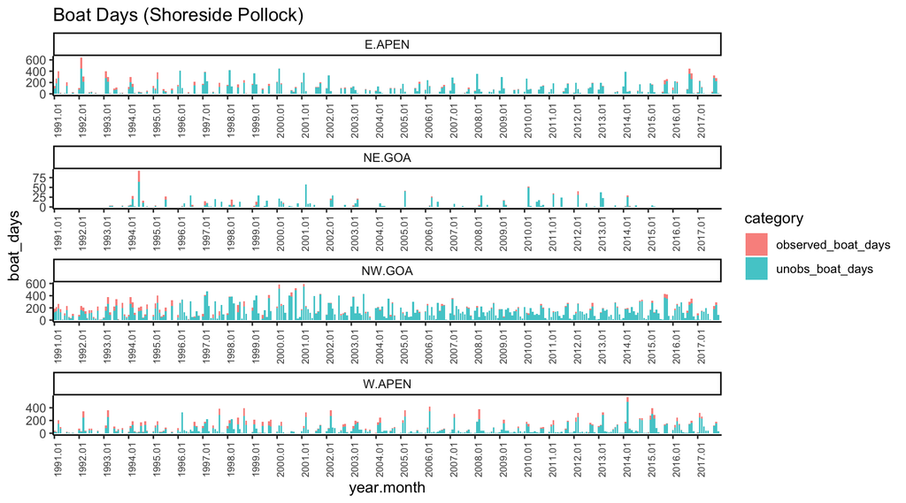

Stacked bar plots summarized by season

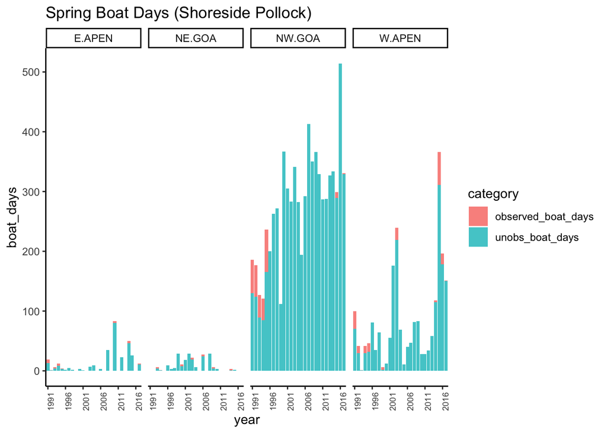

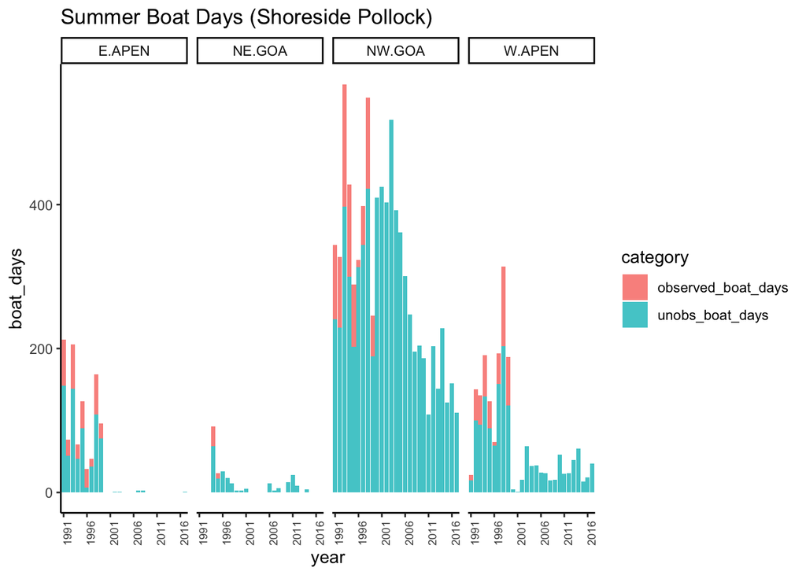

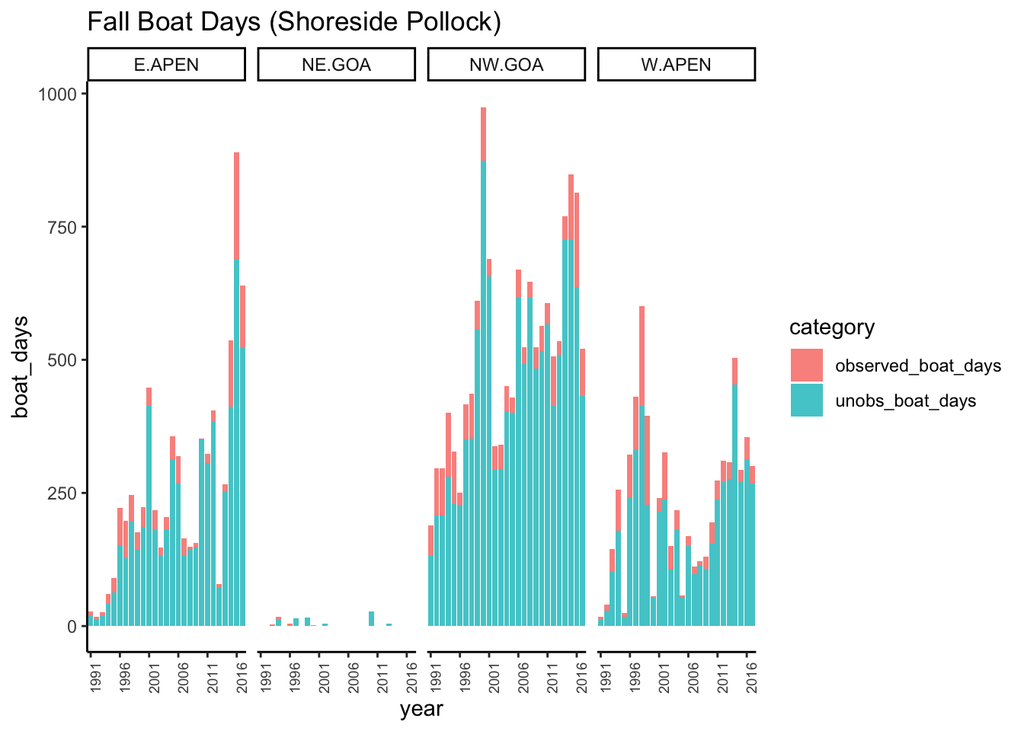

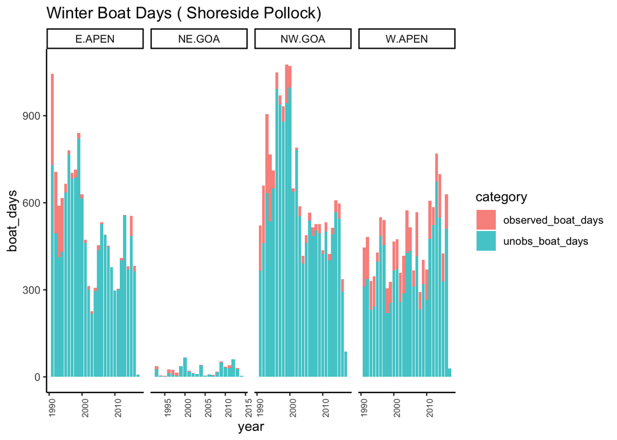

How long do trips tend to be?

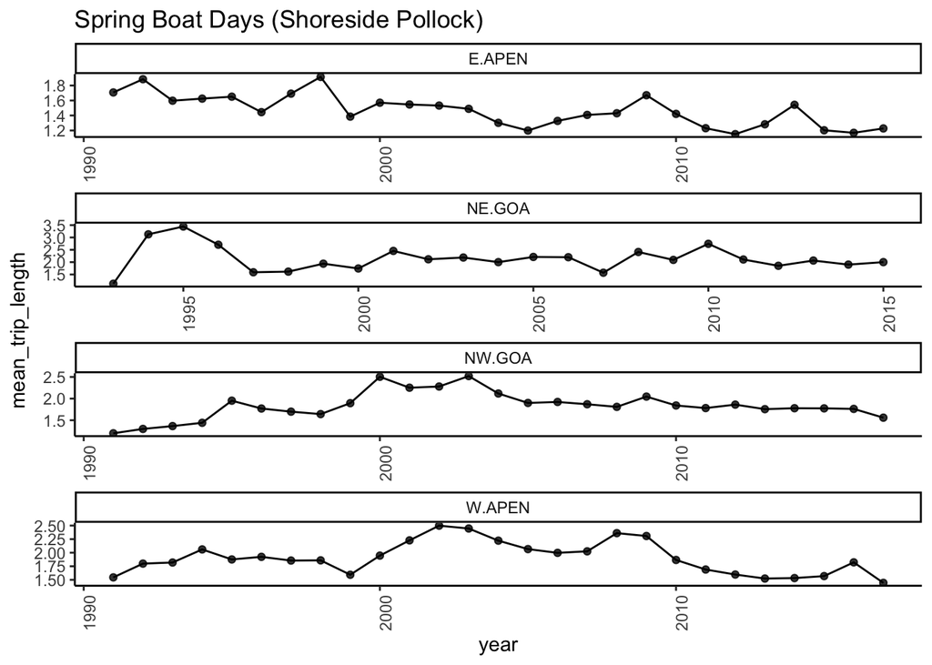

Fraction of Boat Days with an observer onboard. Black = no effort, white = no observed effort

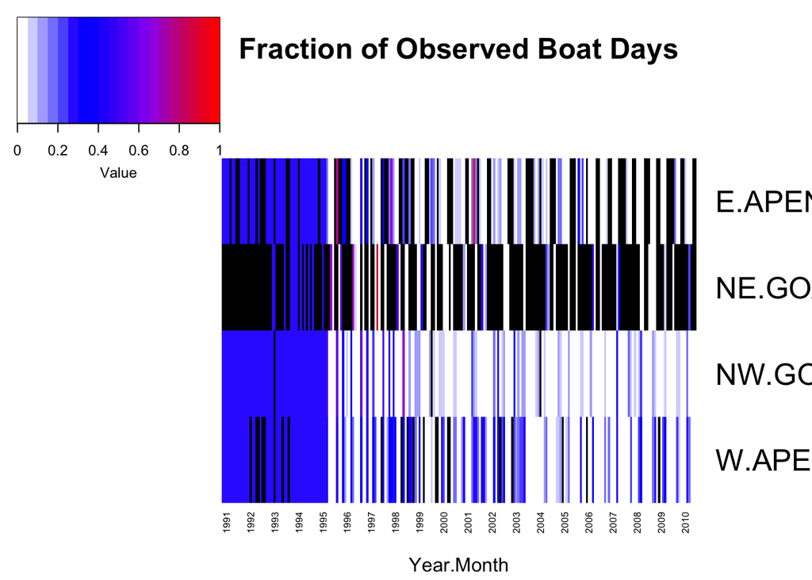

If there is an observer on board- how much of the catch are they surveying? 10% unless a vessel delivers to a tender, than 0%— Below is a summary of fraction of total Chinook sampled per trip, given there is an observer onboard. Any fraction less than 10% means that some trips during that month were delivered to a tender.

This data comes from “Chinooky_rates_merged.RDS”, the tender delivery difference only started after ~2010 so these data are appropriate to use, earlier years are 10%

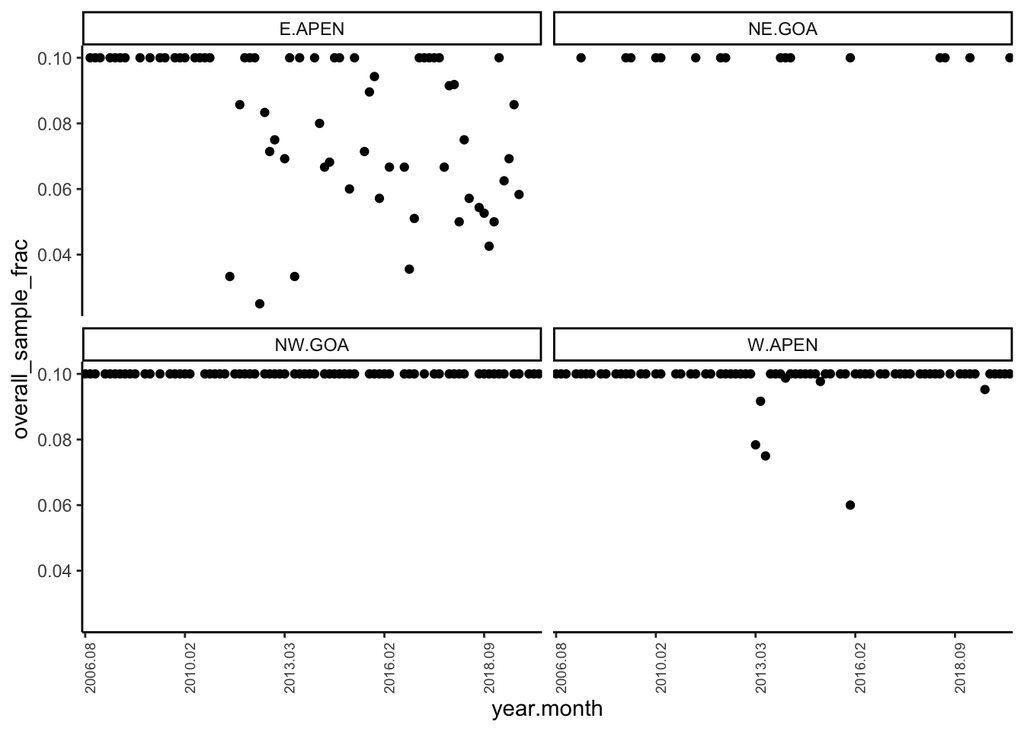

Does effort generally line up with RMIS recoveries? [using RMIS recoveries from all stocks]

Plot observed effort and recoveries- looks ok there aren’t too many lone pink bars (indicates recovery occured but no data for the observed effort)

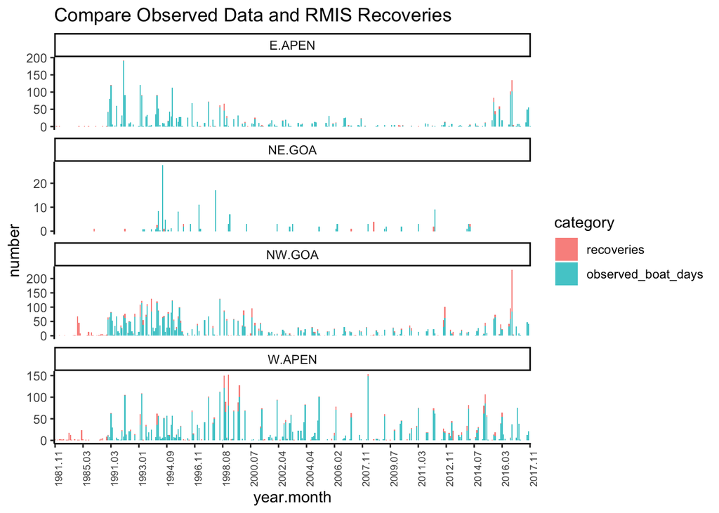

Heatmap plot of total sample fraction

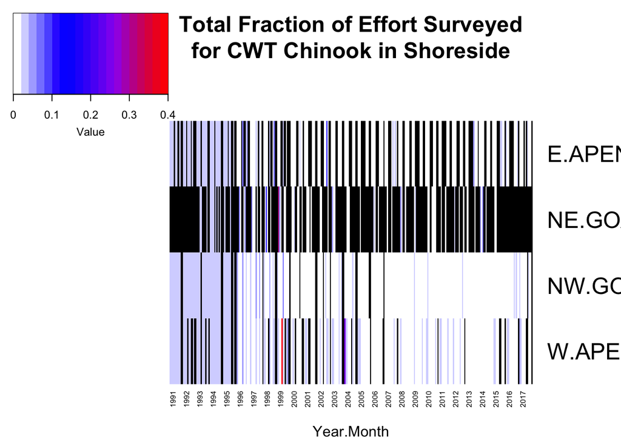